# Rapid Assesment of the Driftless Region

Cole Boninio and Randy Swaty

11/27/2019

## The Driftless Region

Each morning, the sun rises over the Oak savannahs and prairies of the Driftless region. The sunshine envelopes moss-covered bluffs and rocky ridges, unscathed by land carving glaciers. Located in south-western Winsconsin, south-eastern Minnesota, north-eastern Iowa, and the very north-west corner of Illinois, the Driftless region is home to a variety of unique flora and fauna.

Waking in the warmth of the morning sun, various small mammals like squirrels, mice, and voles scuttle amongst fallen oak leaves, munching into seeds and acorns. Many birds use the prairies for nesting including eastern kingbird, indigo bunting, and eastern bluebird.Larger fauna like White-tail deer, elk, and coyote wade through the tall prairie grasses and wildflowers. Grasses include big and little blue-stem, Indian grass, northern drop-seed, purple love grass, June grass, and numerous other species. Forbs include pasque flowers, lead-plants, shooting-stars, fringed puccoons, compass-plants, blazing-stars, purple prairie-clovers, yellow coneflower, black-eyed susan, sunflowers, goldenrods, and asters. Due to the presence of both grassland and woodland, Oak savannas contain far more biodiversity than either of the two alone.

The rugged beauty of the Driftless region attracts a variety of nature-lovers, hikers, bikers, and fishermen alike! Winsconsin-born naturalist John Muir recounts his appreciation of his childhood home, “Here, without knowing it, we still were at school; every wild lesson a love lesson, not whipped but charmed into us. Oh, that glorious Wisconsin wilderness!”

## Historic Vegetation Patterns

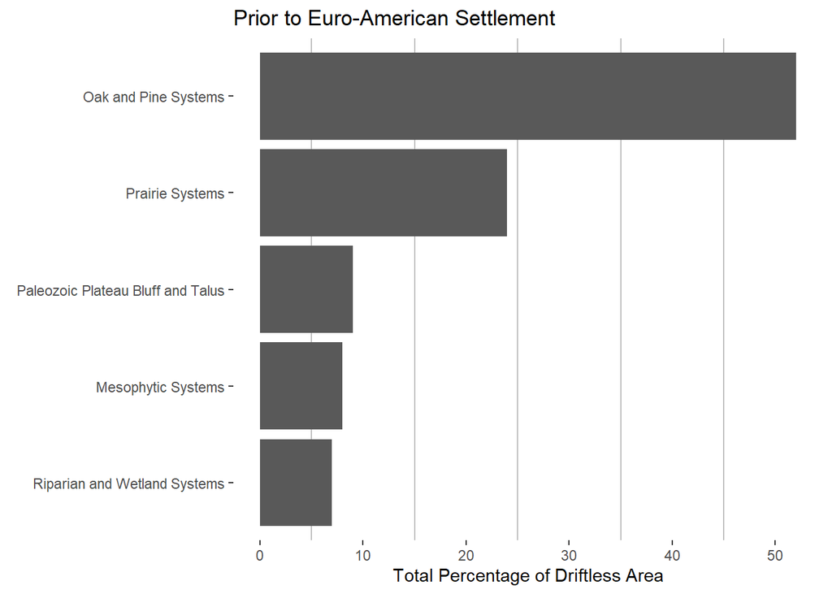

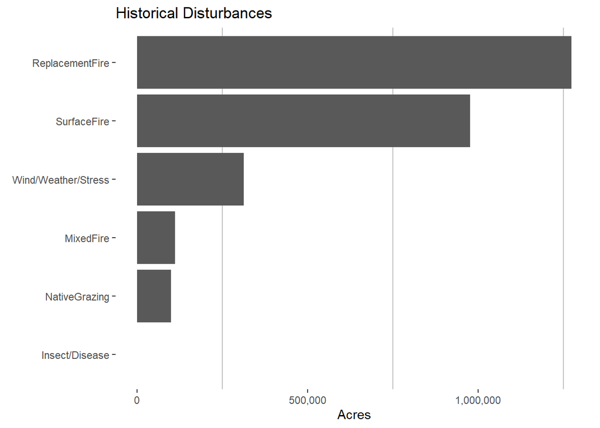

## Current Vegetation Patterns

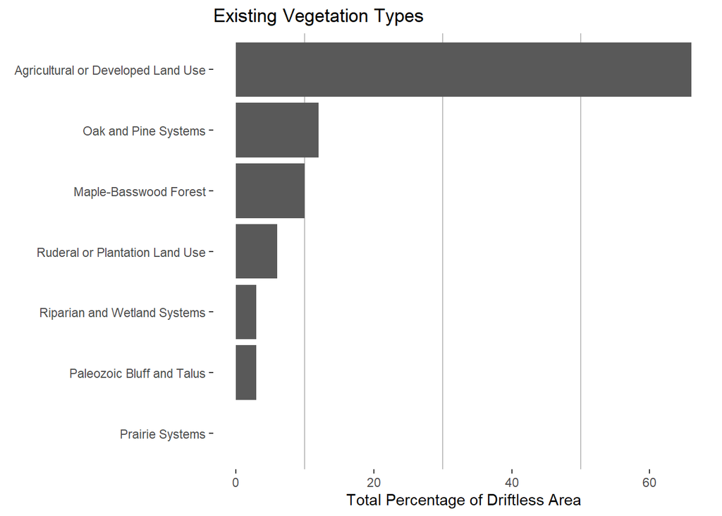

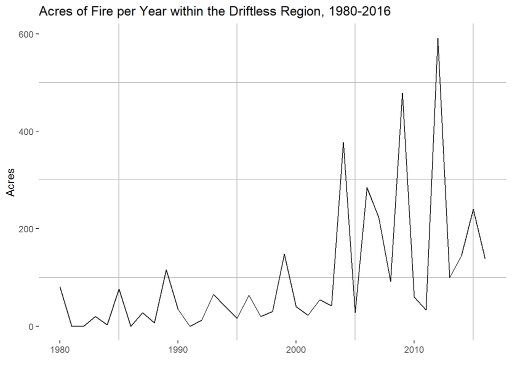

## Past VS. Present

### What is the current vegetation cover like in the main ecosystems of the Driftless Region?

Vegetation cover is a defining characteristic of an ecosystem. That is, for any ecosystem how much of it is herbaceous or tree vegetation, and how dense is the vegetation?

We can compare current vegetation cover to estimated historic, or reference cover to get a sense of how structurally departed an ecosystem is from natural conditions, and what we might need to do about it. For example, for many eastern oak ecosystems if the canopy cover is too great, then the native diversity of understory vegetation declines, as does regeneration of oaks. If canopy closure is too high, **and** if “desireable” tree species are in the understory, then thinning might be advised.

### Methods

We can explore potential ecosystem distribution and current cover conditions by combining LANDFIRE Existing Vegetation Cover and Biophysical Settings (historical ecosystem) data for the region of interest, in this case the Driftless Region of the Midwestern United States. We did this combine in ArcGIS, the exported the resulting attribute table to Excel.

To make exploration easier (and arguably so that it makes more sense) we first removed agricultural and developed lands, then combined multiple LANDFIRE BpSs into “Groups” in an Excel pivot table. For example, we combined 7 BpSs into the “Oak and Pine Systems” group.

We then created the “sunburst” plot below in R using the "sunburstR’ package.

## Explore

In the sunburst chart below you can explore the canopy cover per ecosystem patterns by first hovering over the inner ring to get the percentage of each ecosystem, then moving your cursor outward to explore canopy closure per ecosystem. Percentages will appear in the middle of the chart, and the “path” (e.g., “Oak and Pine systems > Tree Cover >= 70% and < 80% = 17.6%”) will appear to the top right.

The canopy closure percentage colors stay consistent from ecosystem to ecosystem, and add up to 100%.

[interactive chart not shown]

## Comparing historical to current vegetation

Of the roughly 16M acres that are the Driftless Region 11+M acres (~70%) have been converted to agricultural or developed land use. Of the remaining unconverted lands some have shifted in type. For example, over 865k acres if what was mapped as Oak and Pine systems is mapped as Maple-Basswood today, presumably due to fire suppression. To explore patterns of change interact with the chord diagram below.

### Chord diagram of ecosystem changes

To visualize patterns of change between the historical and current ecosystems we combined the LANDFIRE Biophysical Settings and Existing Vegetation Type datasets, then “cleaned”, or grouped the vegetation types into similar categories. We then used that data to generate the interactive chord chart below.

Hover over the outside ring segments. For example, if you hover over the darkest green segment of the “Agricultural or Developed Land Use” you will see which ecosystems, and how much of each has been converted. We find that most of what is now Agricultural or Developed Land use came from areas formerly mapped as Oak and Pine. Conversely, if you hover over the outside grey segment of Historically Pine and Oak Systems you’ll see that very little of that type remains, and that a fair amount has shifted to Maple-Basswood.

[interactive chart not shown]

### Limitations

The LANDFIRE Biophysical Settings (representing historical) and Existing Vegetation Type datasets were generated using very different methods and are designed for use over large landscapes. These visualizations are for exploring patterns and for identifying potential future research.